# Risk and self-governance

Moral communication with English life-sentenced prisoners through the medium of risk management

[Ben Jarman](https://changinginside.co.uk)

ben@bmhj.simplelogin.com

[Birkbeck, University of London](https://icpr.org.uk)

12th September 2024

## ‘Tight’ risk intervention as a pain of imprisonment

> “Increasingly, prisoners are no longer objects of punishment, but made instead into potential subjects of self-change, thus creating prisons characterized by what Crewe has called ‘neo-paternalism’. [It communicates] the need to self-govern, take responsibility and show credible change and growth.”

> Ugelvik and Damsa (2018, 1028), referencing Crewe (2009, 2011)

## ‘Tight’ intervention as (sometimes) welcome

> “[P]risoners often welcome institutional attention […] when it is supportive rather than coercive, and where it [engages] with [their] full personhood rather […] refracting [their] selfhood through the limiting prism of cognitive behavioural discourse.”

> Crewe and Ievins (2021, 65)

Fergus McNeill (2019; see also McNeill *et al.* 2018) also explores how different styles of intervention are experienced with differing perceived legitimacy.

## The puzzle

- If prisons exercise power ‘loosely’ as well as ‘tightly’, then which prisoners experience power in each way?
- At what points in a long or indeterminate sentence are these experiences salient?
- How are their index offences and former biographies implicated?

## The research

- Cross-sectional study, focused on ethical experience
- Sample: 48 men serving mandatory life sentences for murder
- Two sites:
  - HMP Swaleside (category B, a large, complex, violent, long-term prison)
  - HMP Leyhill (category D, open prison specialising in high-risk releases)
- Semi-structured life and prison history interviews
- Documents relating to the offence, sentence planning, and risk
- Research questions
  - How do lifers respond to moral messages about their past conduct?
  - What ethical priorities do they adopt as the sentence proceeds?
  - How do personal ethics interact with demands to self-govern and ‘reduce risk’?

A life sentence is the mandatory punishment for murder in the UK.

# Research methods

## Design and data

- Cross-sectional study, two contrasting sites
  - Swaleside - category-B
  - Leyhill - category-D
- Sample: 48 men serving mandatory life sentences
- Semi-structured interviews and document analysis

# Risk and moral communication at the two sites

## Assessed risk in the sample

- Generally ‘low’ risk of reconviction
- Higher risk of serious harm in community than in custody

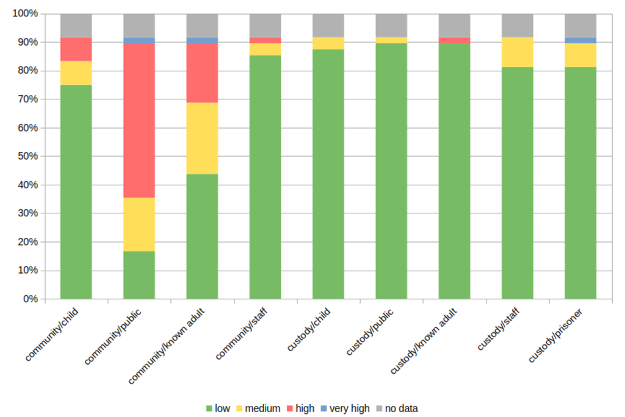

Risk of Serious Harm assessments for the sample (n=44)

## Contrasting moral communication styles: Swaleside

- Swaleside: ‘loose’ or ‘lax’ approach to risk[^1]
- Vague, infrequent communication
- Focus on compliance and order maintenance
- ‘Neglect’ (benign?)

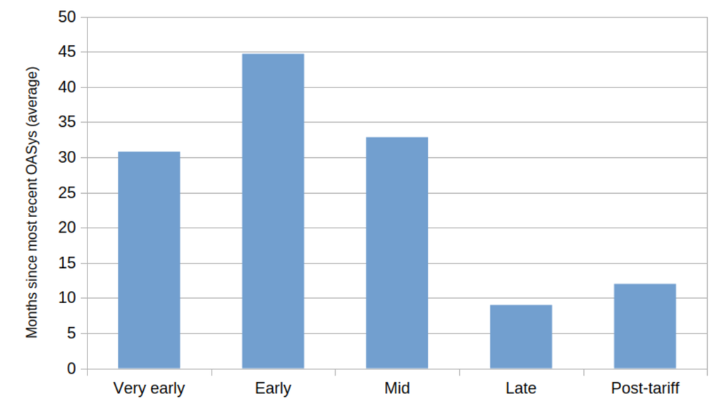

> I don’t know what my sentence plan is […] I just get my recat paper every year and they tell me you ain’t done no courses. I ain’t got a clue what I’ve got to do […] They just leave you to it.

> (Yakubu - Swaleside, twenties, early)

> I just used to dutifully fill it in, put my little bit on there, post it back, and I’d get knocked back. The reason given is because my OASys isn’t up to date […] No fault of my own, it’s just that they haven’t done their job.

> (Grant - Leyhill, fifties, late)

> This jail here, this jail is a dumping ground. They don’t care about you, you’re just here, you’re paying their wages. Do you think they really care?

> (Nixon - Swaleside, forties, post-tariff)

## Contrasting moral communication styles: Leyhill

- Leyhill: ‘Tight’ and demanding
- Intensive supervision and distrust
- Heightened focus on risk management
- Detailed assessment, frequent reviews driven by (statutory) parole process

> This place is scared of its own shadow.

> (Fred - Leyhill, fifties, post-tariff)

> It’s Groundhog Day […] guys that know each other, every time we pass each other, we go ‘unnnggghhhhh!’ Zombieland—it’s Zombieland!

> (Fred - Leyhill, fifties, post-tariff)

> Walking on eggshells, that’s what it’s going to be. Out there people can just easily pick the phone up and say, ‘He’s threatened me.’ I’d get armed response at my house for that.

> (Warren - Leyhill, thirties, late)

## ‘Tight’, ‘loose’, or ‘lax’?

- ‘Tight’ social control is intermittent[^2]
  - Its intensity is driven by official (not personal) agendas
- ‘Dead’ or ‘nothing’ time is inevitable
  - How it is experienced varies

> A decision comes: either you lock off the past, you decide you’re gonna move forward, and you do your courses and work for your own future, or you don’t. You can stay in prison and be a wanker, or you can lock off and get out.

> (Mark - Swaleside, thirties, post-tariff)

> Obviously my last sentence plan at [category-A prison], they set me goals. I’ve achieved most if not all of those […] So they need to set me some new ones […] It’s like, ‘stay out of trouble, continue education’, yeah? That’s kind of vague. […] I do believe I need a bit more structure.

> (Leon - Swaleside, forties, mid)

> They’re saying, ‘Yes, but what is the achievable goal?’ I’m saying, ‘Well, that is achievable. How do you think there are artists? Because they set out to achieve it, and they’ve achieved it.’

> (Dalton - Leyhill, thirties, mid)

# Ethical responses to risk governance

(A typology, using the metaphor of styles of interaction with the ‘tidal pull’ of the sentence.[^3])

## ‘Resisting the tide’

- Rejecting demands for reform
- Maintaining innocence or disputing culpability

> So they said that Nasim’s past and current convictions are evidence of a lack of respect for society and the law […] And this is all nonsense because there’s no evidence in this conviction [for me having] a lack of respect for society and law.

> (Nasim - Swaleside, forties, post-tariff)

> They decided that I should do TSP […] They also suggested that I should do Victim Awareness and Healthy Relationships. There’s no arguing with them […] I’ve told them that they are basing this on OASys that’s full of mistakes […] but they said, ‘Well, we don’t have anything else to go on so […] we don’t care.’

> (Janusz - Swaleside, thirties, mid)

> This is where I’m trying to say to them, ‘Look, what do you want me to change?’ […] You can’t change a violent or bad person by leaving them in this environment.

> (Courtney - Swaleside, forties, late)

## ‘Treading water’

- Delaying engagement with risk reduction
- Focus on survival, conviviality, and personal projects

> Get the Xbox out, play FIFA… You can cook, sit down, have a talk with your friends and that […] We watch boxsets and stuff like that, music.

> (Ebo - Swaleside, twenties, mid)

> I’m getting the books, I’m starting to read them, and, you know, I can read music! I mean, not very well… I can tell you what the notes are, and where they appear on the guitar neck, you know? And it’s just learning, really.

> (Matt - Swaleside, fifties, very early)

> No, no, no, no, no. There’s no sentence plan. No need. Got waaaaay too long […] I’m going to be a pensioner when I get out. You know, there’s no cause to.

> (Matt - Swaleside, fifties, very early)

## ‘Drifting’

- Ignoring (not deferring) official risk narratives
- Pursuing private (often metaphysical) ethical projects and goals

> [My licence] says not to have contact with children under the age of sixteen, yes? Well, I’m not in for a charge like that, for children. I never have been. And [yet] that’s one of my conditions.

> (Jeff - Leyhill, fifties, post-tariff)

> Whatever I do, whether it be getting a smart phone, whether it be having contraband or refusing to do something that officers are telling me, my motives or my reasoning behind it is almost… Like, there is a method to my madness.

> (Simeon - Swaleside, twenties, late)

> I hate parole boards. What they do is… they’re just digging in the shit that I planted roses in years ago, if you know what I mean. They still want to see shit, and it’s gone […] I’ve even sat on the parole board and said, ‘you know what, I couldn’t give a flying fuck if you let me out or not. I’m free inside. You don’t understand that.’

> (Fred - Leyhill, fifties, post-tariff)

## ‘Swimming onwards’

- Accepting risk management as legitimate
- Actively engaging in self-governance

> I think the system is invested in people that want to help themselves […] I feel, since I’ve been here especially, they’re helping me to get out of the door, pushing me in that direction.

> (Daniel - Leyhill, fifties, late)

> What I was like, what I am, who I am, what I’m capable of. They’re just basic facts now, and I have to accept that […] I can change myself […] But it doesn’t change the facts.

> (Billy - Swaleside, forties, late)

> See, for me [risk-reducing courses] are about the skills that you need to understand yourself. You can only do that yourself […] If you open up and allow yourself to be so red and raw with your emotions, with your thoughts, then you’re going to gain out of it.

> (Nicholas - Leyhill, thirties, post-tariff)

# Implications and theoretical contributions

## Ethical ‘crunch points’

- Periods of intensified scrutiny and expectations
- Often driven by the sentence length (institutional)
- ‘End-to-end offender management’ in an age of fiscal retrenchment—an example of hubris?[^4]
- Impact on prisoners’ ethical stances

## Nuancing the ‘tightness’ framework

- Variation in risk management experiences
  - Pains of ‘tightness’ unevenly distributed, spatially and longitudinally
- Influence of prison type and sentence stage

## Linking to sentencing theories and practices

- Key points to explore:
  - Tensions between retributive and risk-based approaches to sentencing
  - Implications for the legitimacy and effectiveness of long-term imprisonment, in light of lowered then raised expectations

## Methodological contributions

- Value of comparing contrasting prison sites
- Insights from combining risk documents and prisoner narratives

# Conclusion

- Diverse ethical responses to risk governance
- Importance of understanding individual adaptations to long-term imprisonment
- Implications for policy and practice in risk management

# References

**Crewe B** (2009) *The prisoner society: Power, adaption, and social life in an English prison*. Oxford: Oxford University Press. [https://doi.org/10.1093/acprof:oso/9780199577965.001.0001/.](https://doi.org/10.1093/acprof:oso/9780199577965.001.0001/)

**Crewe B** (2011) Depth, weight, tightness: Revisiting the pains of imprisonment. *Punishment & Society* **13**(5), 509–529. [https://doi.org/10.1177/1462474511422172.](https://doi.org/10.1177/1462474511422172)

**Crewe B, Hulley S and Wright S** (2017) Swimming with the Tide: Adapting to Long-Term Imprisonment. *Justice Quarterly* **34**(3), 517–541. [https://doi.org/10.1080/07418825.2016.1190394.](https://doi.org/10.1080/07418825.2016.1190394)

**Crewe B and Ievins A** (2019) The prison as a reinventive institution. *Theoretical Criminology* https://doi.org/10.1177/1362480619841900. [https://doi.org/10.1177/1362480619841900.](https://doi.org/10.1177/1362480619841900)

**Crewe B and Ievins A** (2021) ‘Tightness’, recognition and penal power. *Punishment & Society* **23**(1), 47–68. [https://doi.org/10.1177/1462474520928115.](https://doi.org/10.1177/1462474520928115)

**HM Inspectorate of Probation and HM Inspectorate of Prisons** (2022) *Offender Management in Custody – pre-release: A joint inspection by HM Inspectorate of Probation and HM Inspectorate of Prisons* (Thematic Inspection). Manchester: HM Inspectorate of Probation. Retrieved from https://www.justiceinspectorates.gov.uk/hmiprobation/wp-content/uploads/sites/5/2022/11/OMiC-joint-thematic-inspection-report-v1.0.pdf

**McNeill F** (2019) *Pervasive punishment: making sense of mass supervision*, First edition. Bingley, UK: Emerald.

**McNeill F, Mark, Thomas O and Thornden-Edwards K** (2018) Helping, Holding, Hurting: A Conversation about Supervision. *The Howard Journal of Crime and Justice* **57**(1), 94–106. [https://doi.org/10.1111/hojo.12240.](https://doi.org/10.1111/hojo.12240)

**Ministry of Justice and HM Prison & Probation Service** (2018, September 12) Manage the custodial sentence: policy framework. Ministry of Justice. https://www.gov.uk/government/publications/manage-the-custodial-sentence (accessed 9 July 2020)

**Ugelvik T and Damsa D** (2018) The Pains of Crimmigration Imprisonment: Perspectives From a Norwegian All-foreign Prison. *The British Journal of Criminology* **58**(5), 1025–1043. [https://doi.org/10.1093/bjc/azx067.](https://doi.org/10.1093/bjc/azx067)